# Headcount

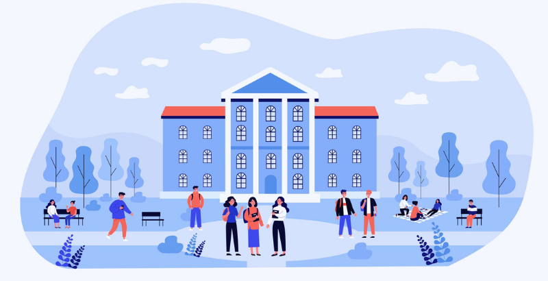

Headcount is the unique count of students enrolled at Utah Tech University for a specific period of time and is essential for both reporting and inquiry.

## Point In Time Headcount

The Point In Time Headcount offers a daily glimpse into enrollment, detailing the term, date, number of days until term start, and the day’s total enrollment headcount.

```sql
/*
daily headcount
*/

SELECT term_id,
       date,
       date_part('week', date) - 11 AS week,
       days_to_class_start,
       COUNT(DISTINCT student_id) AS headcount
FROM export.daily_enrollment
WHERE is_current_term IS TRUE -- Only pulling current term
  AND is_enrolled IS TRUE
GROUP BY term_id, date, days_to_class_start
ORDER BY date DESC;
```

## Current Headcount

The Current Headcount reflects the live count of enrolled students for a term, which can fluctuate daily and may be adjusted post-term for changes like withdrawals.

```sql
/*
Current headcount
*/

SELECT a.term_desc,
       COUNT(a.student_id) AS current_headcount
FROM export.student_term_level_version a
         LEFT JOIN export.term b
                   ON a.term_id = b.term_id
WHERE a.is_enrolled IS TRUE
  AND a.is_primary_level IS TRUE
  AND a.version_desc = 'Current'
  AND DATE_PART('year', NOW()) - b.academic_year_code :: INT <= 5 -- Current year plus last 5 years
GROUP BY a.term_desc
ORDER BY a.term_desc;
```

## Census Headcount

The Census Headcount is a fixed count of students enrolled by the 15th day of instruction, used for static reporting.

The 15th day of instruction aligns with the last day of the term to drop without receiving a “W” grade and is the last day to receive a full refund.

```sql
/*
Census/3rd Week headcount
*/

SELECT a.term_desc,
       COUNT(a.student_id) AS census_headcount
FROM export.student_term_level_version a
         LEFT JOIN export.term b
                   ON a.term_id = b.term_id
WHERE a.is_enrolled IS TRUE
  AND a.is_primary_level IS TRUE
  AND a.version_desc = 'Census'
  AND DATE_PART('year', NOW()) - b.academic_year_code :: INT <= 5 -- Current year plus last 5 years
GROUP BY a.term_desc
ORDER BY a.term_desc;
```

## End of Term Headcount

The End of Term Headcount tallies students enrolled at semesters end, including high school concurrent enrollments, providing another static figure for reporting.

```sql
/*
End of Term headcount
*/

SELECT a.term_desc,
       COUNT(a.student_id) AS eot_headcount
FROM export.student_term_level_version a
         LEFT JOIN export.term b
                   ON a.term_id = b.term_id
WHERE a.is_enrolled IS TRUE
  AND a.is_primary_level IS TRUE
  AND a.version_desc = 'End of Term'
  AND DATE_PART('year', NOW()) - b.academic_year_code :: INT <= 5 -- Current year plus last 5 years
GROUP BY a.term_desc
ORDER BY a.term_desc;
```

## IPEDS Fall Enrollment Headcount

For annual reporting, the IPEDS Fall Enrollment Headcount uses the Fall census data, while the IPEDS 12 Month Enrollment Headcount gathers year-round credit enrollment figures.

For the sql, see Census Headcount above

## IPEDS 12 Month Enrollment Headcount

The IPEDS 12 Month Enrollment Headcount aims to collect comprehensive enrollment data over a 12-month period. This includes unduplicated census counts of all students enrolled for credit, capturing the full scope of instructional activity throughout the year.

```sql
/*
IPEDS 12 Month headcount
 */

SELECT b.academic_year_code,
       COUNT(DISTINCT a.student_id) --unduplicated students over the course of an academic year
FROM export.student_term_level_version a
         LEFT JOIN export.term b
                   ON a.term_id = b.term_id
WHERE a.is_enrolled = TRUE
  AND a.is_primary_level = TRUE
  AND a.version_desc = 'Census'
  AND DATE_PART('year', NOW()) - b.academic_year_code :: INT = 1 -- Last academic year
  AND b.season != 'Summer'                                       -- remove summer as per ipeds requirement
GROUP BY academic_year_code;
```

## USHE Headcount

The USHE Headcount provides a comprehensive view of enrollment by reporting the unduplicated net headcount five times each fiscal year:

- Summer End of Term: Captures enrollment at the conclusion of the summer term.
- Fall Census: Records enrollment as of the 15th day of instruction for the fall term.
- Fall End of Term: Tallies enrollment at the end of the fall semester.
- Spring Census: Documents enrollment on the 15th day of instruction for the spring term.
- Spring End of Term: Counts enrollment at the close of the spring semester.

**Census**: USHE Census Headcount is the net unduplicated number of students enrolled as of the 15th day of instruction of an academic term. Census headcount is based on snapshot data, this headcount returns a static headcount and may be modified to meet USHE reporting element criteria.

For the sql, see Census Headcount above

**End of Term**: USHE End of Term Headcount is the net unduplicated number of students enrolled at the end of the semester and after the high school concurrent enrollment grades are entered. Based on snapshot data, this headcount returns a static headcount and may be modified to meet USHE reporting element criteria.

For the sql, see End of Term Headcount above